# EXPLORATORY DATA ANALYSIS (EDA) OF TA-FENG Store

```python
# # import image module
# from IPython.display import Image

# # get the image
# Image(url="https://media.istockphoto.com/id/693171708/photo/fresh-vegetables-on-shelf-in-supermarket.jpg?b=1&s=170667a&w=0&k=20&c=k9FQdzjHesVOCa0AAFXTqTU65Ti1otGjEruDBDbraTk=", width=1200, height=300)
```

[figure not shown]

## INTRODUCTION TO THE PROJECT

Ta-Feng Store is a Chinese grocery store that keep daily record of products sold with their respective sales prices. The format of the store data collection is as follows: TRANSACTION_DT, CUSTOMER_ID, AGE_GROUP, PIN_CODE, PRODUCT_SUBCLASS, PRODUCT_ID, AMOUNT, ASSET, SALES_PRICE.

My interest is to explore the transactions of Ta-Feng Store, with the aim of answering question which will help see the pattern in the transaction of Ta-Feng Store.

### Exploratory Data Analysis (EDA)

Data analysis is one of the engine powers of a successful business, it is important to note that in order to make data-driven decision for businesses, the relevance of data analytics can not be overemphasized.

EDA is a process of analyzing data sets to summarize their main characteristics, often using statistical methods to discover pattern in the data set and other data visualization methods. EDA gives an overview of what our data is capable of doing and to guide the process of answering research questions.

The project will see me demonstrating the tools of EDA learned during the course of my learning at: https://jovian.ai/learn/data-analysis-with-python-zero-to-pandas through the use of relevant tools such: Python Libraries(Numpy, Pandas, Seaborn, Matplotlib and so on), Jupyter Notebook

### Contents of the Project

- Downloading the Dataset
- Data Preparation and Cleaning
- Exploratory Analysis and Visualization
- Asking and Answering Questions
- Inferences and Conclusion
- References and Future Work

### Details about the dataset

The dataset contains a Chinese grocery store transaction data from November 2000 to February 2001.

Data source: https://www.kaggle.com/datasets/chiranjivdas09/ta-feng-grocery-dataset

#### Features of data set

- TRANSACTION_DATE
- CUSTOMER_ID
- AGE_GROUP
- PIN_CODE
- PRODUCT_SUBCLASS
- PRODUCT_ID
- AMOUNT
- ASSET
- SALES_PRICE

### Tools Used

- Python as Language
- jupyter notebook hosted on Jovian.ml : Data Analysis with Python: Zero to Pandas
- Python Libraries (Numpy, Pandas, Matplotlib, Seaborn)

## Downloading the Dataset

### The dataset from Kaggle will be downloaded by following some steps, which are highlighted below.

```python
!pip install jovian opendatasets --upgrade --quiet
```

Let's begin by downloading the data, and listing the files within the dataset.

```python
dataset_url = 'https://www.kaggle.com/datasets/chiranjivdas09/ta-feng-grocery-dataset'
```

```python
import opendatasets as od
od.download(dataset_url)
```

```
Skipping, found downloaded files in "./ta-feng-grocery-dataset" (use force=True to force download)
```

The dataset has been downloaded and extracted.

```python
data_dir = './ta-feng-grocery-dataset'
```

```python
import os
os.listdir(data_dir)
```

```
['ta_feng_all_months_merged.csv']
```

Let us save and upload our work to Jovian before continuing.

```python
project_name = "ta-feng-grocery-dataset" # change this (use lowercase letters and hyphens only)
```

```python
!pip install jovian --upgrade -q
```

```python
import jovian
```

```python
jovian.commit(project=project_name)
```

```
[jovian] Updating notebook "tunjistic17/ta-feng-grocery-dataset" on https://jovian.ai
[jovian] Committed successfully! https://jovian.ai/tunjistic17/ta-feng-grocery-dataset
```

```
'https://jovian.ai/tunjistic17/ta-feng-grocery-dataset'
```

## Data Preparation and Cleaning

At this section, we will prepare the data and clean it before analyzing it. Missing values will be handled.

```python
import numpy as np
import pandas as pd
```

```python
path = "~/ta-feng-grocery-dataset/ta_feng_all_months_merged.csv"
df = pd.read_csv(path)

# The dataframe has rows and columns

rows_columns = df.shape
print("The dataframe has {} rows and columns respectively".format(rows_columns))
```

```
The dataframe has (817741, 9) rows and columns respectively
```

### Checking the data types of each columns

```python
# Making sure that the data type of each columns is correct
df.dtypes
```

```
TRANSACTION_DT      object
CUSTOMER_ID          int64
AGE_GROUP           object
PIN_CODE            object
PRODUCT_SUBCLASS     int64
PRODUCT_ID           int64
AMOUNT               int64
ASSET                int64
SALES_PRICE          int64
dtype: object
```

##### The data type for our dataset is as expected

### Checking Columns with missing values

```python
df.isna().sum()
```

```
TRANSACTION_DT          0
CUSTOMER_ID             0
AGE_GROUP           22362
PIN_CODE                0
PRODUCT_SUBCLASS        0
PRODUCT_ID              0
AMOUNT                  0
ASSET                   0
SALES_PRICE             0
dtype: int64
```

We can see that the column with the label "AGE_GROUP" has 22362 missing values. Therefore, all the rows will be dropped.

### Dropping the rows with missing values for the column "AGE_GROUP"

```python
# Selecting all rows with missing values of "AGE_GROUP"
a = df[df["AGE_GROUP"].isna()==True]
```

#### Dropping rows with at least one Nan value (Null value)

Since only the column "AGE_GROUP" has missing values, we can drop all its row in the dataframe.

```python
df = df.dropna()
```

### Creating the profit column in the dataframe

```python
df.head(2)
```

|  | TRANSACTION_DT | CUSTOMER_ID | AGE_GROUP | PIN_CODE | PRODUCT_SUBCLASS | PRODUCT_ID | AMOUNT | ASSET | SALES_PRICE |
| --- | --- | --- | --- | --- | --- | --- | --- | --- | --- |
| 0 | 11/1/2000 | 1104905 | 45-49 | 115 | 110411 | 4710199010372 | 2 | 24 | 30 |
| 1 | 11/1/2000 | 418683 | 45-49 | 115 | 120107 | 4710857472535 | 1 | 48 | 46 |

```python
sales_weight = df["AMOUNT"]*df["SALES_PRICE"]
asset_weight = df["AMOUNT"]*df["ASSET"]

profit = sales_weight - asset_weight
profit
df["PROFIT"] = profit
df
```

|  | TRANSACTION_DT | CUSTOMER_ID | AGE_GROUP | PIN_CODE | PRODUCT_SUBCLASS | PRODUCT_ID | AMOUNT | ASSET | SALES_PRICE | PROFIT |
| --- | --- | --- | --- | --- | --- | --- | --- | --- | --- | --- |
| 0 | 11/1/2000 | 1104905 | 45-49 | 115 | 110411 | 4710199010372 | 2 | 24 | 30 | 12 |
| 1 | 11/1/2000 | 418683 | 45-49 | 115 | 120107 | 4710857472535 | 1 | 48 | 46 | -2 |
| 2 | 11/1/2000 | 1057331 | 35-39 | 115 | 100407 | 4710043654103 | 2 | 142 | 166 | 48 |
| 3 | 11/1/2000 | 1849332 | 45-49 | Others | 120108 | 4710126092129 | 1 | 32 | 38 | 6 |
| 4 | 11/1/2000 | 1981995 | 50-54 | 115 | 100205 | 4710176021445 | 1 | 14 | 18 | 4 |
| ... | ... | ... | ... | ... | ... | ... | ... | ... | ... | ... |
| 817736 | 2/28/2001 | 312790 | 35-39 | 114 | 530501 | 4713317035042 | 2 | 80 | 118 | 76 |
| 817737 | 2/28/2001 | 57486 | 40-44 | 115 | 530209 | 4710731060124 | 1 | 40 | 55 | 15 |
| 817738 | 2/28/2001 | 733526 | >65 | Unknown | 510539 | 4716340052307 | 1 | 78 | 115 | 37 |
| 817739 | 2/28/2001 | 173704 | 45-49 | 115 | 520457 | 4714276145315 | 1 | 90 | 96 | 6 |
| 817740 | 2/28/2001 | 1719888 | 30-34 | 221 | 530202 | 4713080610231 | 1 | 158 | 199 | 41 |

795379 rows × 10 columns

### Now, we have clean data for Exploratory Analysis

```python
import jovian
```

```python
jovian.commit()
```

```
[jovian] Updating notebook "tunjistic17/ta-feng-grocery-dataset" on https://jovian.ai
[jovian] Committed successfully! https://jovian.ai/tunjistic17/ta-feng-grocery-dataset
```

```
'https://jovian.ai/tunjistic17/ta-feng-grocery-dataset'
```

## Exploratory Data Analysis and Visualization

At this stage, we will explore our cleaned data for some descriptives statistics. We will investigate our data for patterns, anomalies, distribution with help of summary of aggregation as well as visualization.

### Computing mean, sum, range and other interesting statistics for numeric columns

```python
df.describe()
```

|  | CUSTOMER_ID | PRODUCT_SUBCLASS | PRODUCT_ID | AMOUNT | ASSET | SALES_PRICE | PROFIT |
| --- | --- | --- | --- | --- | --- | --- | --- |
| count | 7.953790e+05 | 795379.000000 | 7.953790e+05 | 795379.000000 | 795379.000000 | 795379.000000 | 7.953790e+05 |
| mean | 1.391069e+06 | 285222.685594 | 4.462025e+12 | 1.382472 | 112.201554 | 131.978613 | 6.071352e+01 |
| std | 6.111713e+05 | 226555.280420 | 1.689665e+12 | 2.930321 | 611.033101 | 638.552881 | 1.091487e+04 |
| min | 1.250000e+03 | 100101.000000 | 2.000882e+07 | 1.000000 | 0.000000 | 1.000000 | -2.215200e+05 |
| 25% | 9.567650e+05 | 110106.000000 | 4.710085e+12 | 1.000000 | 35.000000 | 42.000000 | 6.000000e+00 |
| 50% | 1.582789e+06 | 130106.000000 | 4.710421e+12 | 1.000000 | 62.000000 | 76.000000 | 1.300000e+01 |
| 75% | 1.858501e+06 | 520320.000000 | 4.712500e+12 | 1.000000 | 112.000000 | 132.000000 | 2.800000e+01 |
| max | 2.179643e+06 | 780510.000000 | 9.789580e+12 | 1200.000000 | 432000.000000 | 444000.000000 | 9.600000e+06 |

```python
#df[["CUSTOMER_ID", "PRODUCT_SUBCLASS", "PRODUCT_ID", "AMOUNT", "ASSET", "SALES_PRICE"]].agg(["mean", "sum", "max", "min"])
```

Let's begin by importing`matplotlib.pyplot` and `seaborn`.

```python
import seaborn as sns
import matplotlib
import matplotlib.pyplot as plt
%matplotlib inline

sns.set_style('darkgrid')
matplotlib.rcParams['font.size'] = 14
matplotlib.rcParams['figure.figsize'] = (9, 5)
matplotlib.rcParams['figure.facecolor'] = '#00000000'
```

Explore Asset and Age Group columns with visualizing

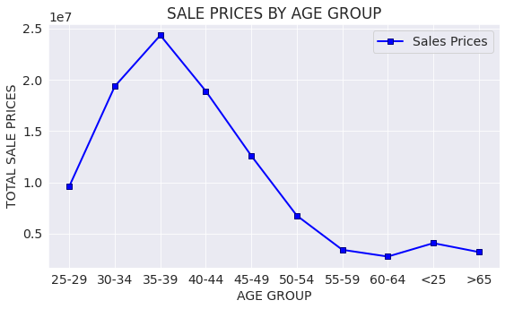

```python
# Calculating the average of asset and grouping by "AGE_GROUP"

x_age_group = df.groupby("AGE_GROUP").SALES_PRICE.sum()

y_age = df.AGE_GROUP.unique()
y_age = np.sort(y_age)
y_age

plt.plot(y_age, x_age_group, label = "Sales Prices",  marker='s', c='b', ls='-', lw=2, mec='navy')
plt.title("SALE PRICES BY AGE GROUP")
plt.legend()
plt.xlabel("AGE GROUP")
plt.ylabel("TOTAL SALE PRICES")
```

### The line chart above shows how the total sales prices by each age group.

Exploring average of asset and grouping by "AGE_GROUP"

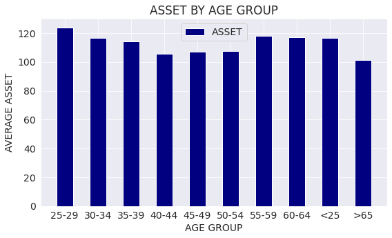

```python
# Calculating the average of asset and grouping by "AGE_GROUP"
y_asset = df.groupby("AGE_GROUP").ASSET.mean()
z_asset = df.AGE_GROUP.unique()
z_asset = np.sort(z_asset)
z_asset
plt.bar(z_asset, y_asset, label = "ASSET", width=.5, color='navy')
plt.title("ASSET BY AGE GROUP")
plt.legend()
plt.xlabel("AGE GROUP")
plt.ylabel("AVERAGE ASSET")
```

### The bar chart above shows the distribution of average asset among the age groups

Exploring the Sales Price and Age Group Columns

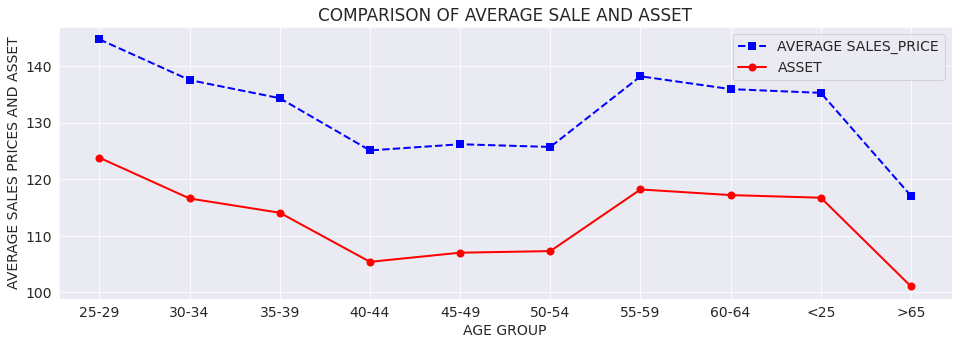

```python
plt.figure(figsize=(16,5))

x_avg_sales = df.groupby("AGE_GROUP").SALES_PRICE.mean()

z_asset = df.AGE_GROUP.unique()
z_asset = np.sort(z_asset)
z_asset

y_asset

plt.plot(z_asset, x_avg_sales, marker='s', c="b", ls="--", ms="6", alpha= True, label = "AVERAGE SALES_PRICE", lw=2,  mew=2, mec='b')
plt.plot(z_asset, y_asset, marker='o', c="r", ls="-", ms="6", alpha = True, label = "ASSET", lw=2,  mew=2, mec='r')
plt.legend()
plt.title("COMPARISON OF AVERAGE SALE AND ASSET")
plt.xlabel("AGE GROUP")
plt.ylabel("AVERAGE SALES PRICES AND ASSET")
```

### The line chart clearly illustrate that the average sales prices are always above the asset across all age group.

Exploring PIN_CODE column

##### Total Quantity of Product sold (AMOUNT) by PIN_CODE

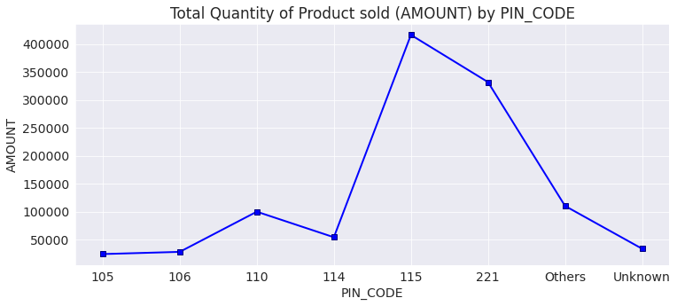

```python
plt.figure(figsize=(12,5))
Amount_by_PIN_CODE= df.groupby("PIN_CODE").AMOUNT.sum()

PIN_CODE = df.PIN_CODE.unique()
PIN_CODE = np.sort(PIN_CODE)
PIN_CODE

plt.plot(PIN_CODE, Amount_by_PIN_CODE, marker='s', c='b', ls='-', lw=2, mec='navy')
plt.title("Total Quantity of Product sold (AMOUNT) by PIN_CODE")
plt.xlabel("PIN_CODE")
plt.ylabel("AMOUNT")
```

### Over 400000 of Product with '115' PIN_CODE was sold

Exploring Profit column by Age Group

```python
profit_by_age_group = df.groupby("AGE_GROUP").PROFIT.sum()
profit_by_age_group

age_group = df.AGE_GROUP.unique()
age_group = np.sort(age_group)
age_group
```

```
array(['25-29', '30-34', '35-39', '40-44', '45-49', '50-54', '55-59',
       '60-64', '<25', '>65'], dtype=object)
```

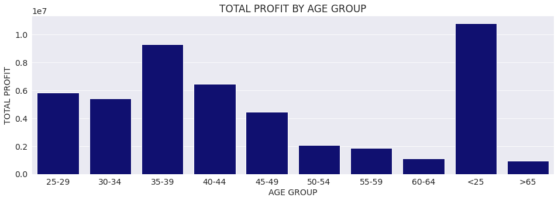

```python
profit_by_age_group = df.groupby("AGE_GROUP").PROFIT.sum()
profit_by_age_group

plt.figure(figsize=(16,5))
sns.barplot(x=age_group, y=profit_by_age_group, color="NAVY")
plt.xlabel("AGE GROUP")
plt.ylabel("TOTAL PROFIT")
plt.title("TOTAL PROFIT BY AGE GROUP")
```

Let us save and upload our work to Jovian before continuing

```python
import jovian
```

```python
jovian.commit()
```

```
[jovian] Updating notebook "tunjistic17/ta-feng-grocery-dataset" on https://jovian.ai
[jovian] Committed successfully! https://jovian.ai/tunjistic17/ta-feng-grocery-dataset
```

```
'https://jovian.ai/tunjistic17/ta-feng-grocery-dataset'
```

## Asking and Answering Questions

The following five questions will be asked and answered which gives us insights into our data and how it can help us make data-driven decisions for the grocery store.

#### Q1: Which of the age group has the highest average profit?

```python
average_profit = df.groupby("AGE_GROUP").PROFIT.mean()
average_profit
```

```
AGE_GROUP
25-29     87.982057
30-34     38.573843
35-39     51.340323
40-44     42.746701
45-49     44.779601
50-54     38.922560
55-59     74.873338
60-64     55.310610
<25      358.878517
>65       34.056082
Name: PROFIT, dtype: float64
```

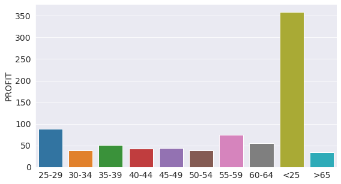

```python
average_profit = df.groupby("AGE_GROUP").PROFIT.mean()

age_group = df.AGE_GROUP.unique()
age_group = np.sort(age_group)
age_group

sns.barplot(x=age_group, y=average_profit);
```

The age group "<25" has the highest average profit.

#### Q2: What are 5 least profits made and on what days 5 days was the least profit made?

```python
total_by_day = df.groupby("TRANSACTION_DT").PROFIT.sum()
days_with_least_profits =  total_by_day.sort_values(ascending=True).head(5)
days_with_least_profits
```

```
TRANSACTION_DT
12/19/2000     8533
12/20/2000    15326
12/22/2000    19432
11/1/2000     20917
12/21/2000    25959
Name: PROFIT, dtype: int64
```

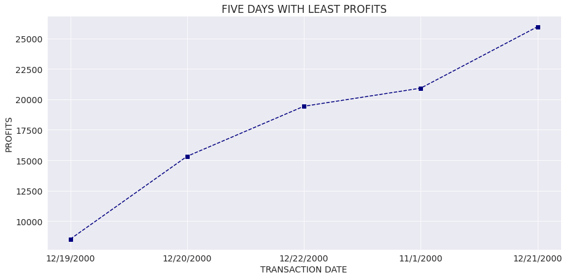

```python
plt.figure(figsize=(15,7))
plt.plot(days_with_least_profits, marker="s", color="navy", ls="dashed")
plt.xlabel("TRANSACTION DATE")
plt.ylabel("PROFITS")
plt.title("FIVE DAYS WITH LEAST PROFITS")
```

##### The line chart above shows the five transaction dates with the least profits

#### Q3: Who are the 20 greatest asset holder in the grocery store using their customer ID?

```python
total_asset = df.groupby("CUSTOMER_ID").ASSET.sum().sort_values(ascending=False).head(20)

total_asset
```

```
CUSTOMER_ID
1622362    445840
1558418    196356
2131269    188395
2119083    172069
2138107    140508
20459      135244
1851588    131396
2112589    129524
2134819    112232
2133874    100497
2141282    100059
2132402     98302
2112596     98279
842419      97730
1062489     94622
2131221     90262
2138077     87401
2133072     85970
2132594     85876
1579727     83250
Name: ASSET, dtype: int64
```

### The Table above shows the total asset by top 20 greatest customer ID.

#### Q4: What are the 20 most profitable Products ?

```python
Product_ID_Profit = df.groupby("PRODUCT_ID").PROFIT.sum().sort_values(ascending=False).head(20)
Product_ID_Profit
```

```
PRODUCT_ID
4711588210441    9611316
8712045008539    1641905
8712045000151    1459660
8712045011317    1041133
4710628119010    1034691
4710628131012     962728
4710114362029     624667
300086780026      579925
4710421090059     562347
7610053910787     470426
4710085150328     459957
7610053910794     396191
4902430493437     367052
4710085104116     365868
20513016          355920
4710094001758     219267
7610053910800     218836
4710154620264     147664
4718647503261     135378
4909978112950     124636
Name: PROFIT, dtype: int64
```

```python
top_20_profitable_product = Product_ID_Profit.index.tolist()
top_20_profitable_product
```

```
[4711588210441,
 8712045008539,
 8712045000151,
 8712045011317,
 4710628119010,
 4710628131012,
 4710114362029,
 300086780026,
 4710421090059,
 7610053910787,
 4710085150328,
 7610053910794,
 4902430493437,
 4710085104116,
 20513016,
 4710094001758,
 7610053910800,
 4710154620264,
 4718647503261,
 4909978112950]
```

```python
print("The following are the 20 top most profitable products  with their ID{}".format(top_20_profitable_product))
```

```
The following are the 20 top most profitable products  with their ID[4711588210441, 8712045008539, 8712045000151, 8712045011317, 4710628119010, 4710628131012, 4710114362029, 300086780026, 4710421090059, 7610053910787, 4710085150328, 7610053910794, 4902430493437, 4710085104116, 20513016, 471009400175…
```

#### Q5: What is the relationship between ASSET and PROFIT?

```python
profit_asset = df[['PROFIT' , "ASSET"]]

x = profit_asset.PROFIT
y= profit_asset.ASSET
```

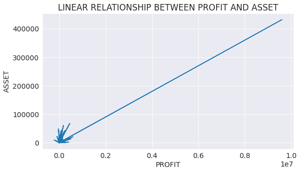

```python
# plotting correlation scatter plot

plt.plot(x, y)
plt.xlabel("PROFIT")
plt.ylabel("ASSET")
plt.title("LINEAR RELATIONSHIP BETWEEN PROFIT AND ASSET")
```

#### Correlation between Profit and Asset

```python
profit_asset.corr()
```

|  | PROFIT | ASSET |
| --- | --- | --- |
| PROFIT | 1.00000 | 0.83825 |
| ASSET | 0.83825 | 1.00000 |

### There is a positive correlation coefficient of 0.83825 between Profit and Asset.

Let us save and upload our work to Jovian before continuing.

```python
import jovian
```

```python
jovian.commit()
```

```
[jovian] Updating notebook "tunjistic17/ta-feng-grocery-dataset" on https://jovian.ai
[jovian] Committed successfully! https://jovian.ai/tunjistic17/ta-feng-grocery-dataset
```

```
'https://jovian.ai/tunjistic17/ta-feng-grocery-dataset'
```

## Inferences and Conclusion

### Inferences

- Customers whose age are less than 25 have the highest average profit in the store.
- There is significant difference between the profits made on various transaction days.
- Some products are more highly profitable while some product only gives rise to enormous loss.
- Some customers have great asset that contribute to the positive profit growth
- There is a positve relationship between ASSET and PROFIT which is about .83825

### Conclusion

- Since large percentage of profit comes from customer whose age are less than 25, it is important to give priority to this fraction of the customer.
- Each days of the week with lesser profit should be studied to understand what factors contributed to it.
- Products with high profit values should be made available in stock always.
- Customers with great asset should be wooed the more to buy profitable products.
- The relations of customers with great asset implies that the higher the asset the higher the profit.

```python
import jovian
```

```python
jovian.commit()
```

```
[jovian] Updating notebook "tunjistic17/ta-feng-grocery-dataset" on https://jovian.ai
[jovian] Committed successfully! https://jovian.ai/tunjistic17/ta-feng-grocery-dataset
```

```
'https://jovian.ai/tunjistic17/ta-feng-grocery-dataset'
```

## References and Future Work

### Suggestions for future work

- Suggestion: The dataset can be used for machine learning to predict the profit in Ta-Feng Grocery-Business
- Even though correlation does not implies casuation, it is important to consider more experiment to determine what is really the trends of profit growth in TA FENG Store.
- The features of the data set could be expanded beyond the present ones.Some of the features could include: Gender, Location, Economic Status, Customer Interest in various product in the store and so on.

### References

- Data Sources: https://www.kaggle.com/datasets/chiranjivdas09/ta-feng-grocery-dataset
- https://jovian.ai/learn/data-analysis-with-python-zero-to-pandas
- https://media.istockphoto.com/id/452568271/photo/two-sales-clerks-standing-in-a-supermarket.jpg
- https://media.istockphoto.com/id/693171708/photo/fresh-vegetables-on-shelf-in-supermarket.jpg
- https://www.geeksforgeeks.org/insert-image-in-a-jupyter-notebook/
- https://jovian.ai/learn/data-analysis-with-python-zero-to-pandas/lesson/lesson-1-introduction-to-programming-with-python
- https://jovian.ai/learn/data-analysis-with-python-zero-to-pandas/lesson/lesson-2-next-steps-with-python
- https://jovian.ai/learn/data-analysis-with-python-zero-to-pandas/lesson/lesson-3-numerical-computing-with-numpy
- https://jovian.ai/learn/data-analysis-with-python-zero-to-pandas/lesson/lesson-4-analyzing-tabular-data-with-pandas
- https://jovian.ai/learn/data-analysis-with-python-zero-to-pandas/lesson/lesson-5-data-visualization-with-matplotlib-and-seaborn
- https://jovian.ai/learn/data-analysis-with-python-zero-to-pandas/lesson/lesson-6-exploratory-data-analysis-a-case-study

```python
import jovian
```

```python
jovian.commit()
```